# Purpose

Create an input file with the proper Operational Taxonomic Units (OTUs) and attributes for each calculation. This function performs two steps to the input file:

1. “Translates” the original TaxonID to the proper OTU based on the selected calculation.
2. Appends the Florida taxa attributes, which include phylogenetic data and traits. For corals, taxon-specific traits include BCG attribute assignments (BCG_ATTR), whether the taxon is ‘Sometimes’ or ‘Never’ weedy (WEEDY), whether the taxon is a ‘Large Reef-Building Coral’ (LRBC), and the Morphological Conversion Factor (MORPHCONVFACT) which is used to calculate Live tissue area on Colony Surface Area (LCSA).

The ‘taxa translator’ and attribute tables are based on reef biomonitoring data from Florida reefs and will be updated regularly.

Download the [Taxa Translator, Taxa Attributes, and Metadata](https://github.com/leppott/BioMonTools_SupportFiles/tree/main/data/taxa_official) from Github page (look for files starting with “FLCoral_BCG_”. Note, that traits are not required for each record (i.e., trait fields allow null values).

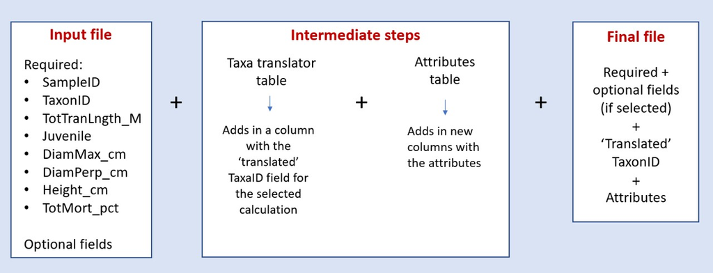

Filebuilder Taxa Translate steps.

# Input File

There are multiple fields that the user is required to provide:

- **SampleID** (Unique sample identifier; typically comprised of the site name, sample date, and replicate number.)
- **TaxaID** (Unique taxa name.)
- **TotTranLngth_M** (Juvenile colonies should be marked as ‘TRUE’.)
- **Juvenile** (Juvenile colonies should be marked as ‘TRUE’.)
- **DiamMax_cm** (Maximum diameter of the colony (cm).)
- **DiamPerp_cm** (Perpendicular diameter of the colony (cm).)
- **Height_cm** (Height of the colony (cm).)
- **TotMort_pct** (% total mortality of the colony (e.g., 58%). Used to calculate % Living Tissue = 100 - TotMort_pct.)

SampleID and TaxaID will be used to match the input file with the taxa translator table and attributes table. It is acceptable for your input file to have these two fields named differently. Click on the drop-down menus. The list of fields in your input file will appear. Select the correct column headings.

Other required fields (i.e., TotTranLngth_M, Juvenile, etc.) and any option fields that should be carried through into the output file (e.g., stationID, collection date, etc.) should be specified by clicking on the ‘Columns to keep in output’ box. The list of fields in your input file will appear. Click on the fields that you want to include. If you change your mind and want to remove a field, click on it and hit ‘delete.’ IMPORTANT: Do not add SampleID or TaxaID to this box as they are already included from the drop-downs above.

# Test File

Download a test file from GitHub: [Example File Builder Input File](https://raw.githubusercontent.com/Blocktt/ShinyAppDocuments/main/FLCoral_BCGCalc/Example_Files/FL_BCG_FileBuilder_Input_20240328.csv).